# Data Visualization Final Project

Melanie Boychuk, Mitch Rimerman, Matt Gnanadass, and Kaitlyn Wood

12/23/2020

## A - Research Questions and Motivation

The aim of this data analysis is to learn about the dynamics of cinema and its audience throughout time. About a year ago, filmmaker Martin Scorsese wrote an opinion piece in the New York Times (https://www.nytimes.com/2019/11/04/opinion/martin-scorsese-marvel.html) defending his claim that Marvel Movies were not cinema. He defined cinema as an art that overwhelms and explores the unknown. He then argued that the almost formulaic Marvel Movies coupled with the rise of streaming make it impossible to overwhelm, to be cinema. Based on his claims, we wanted to explore the trends of the film industry and better understand what its producing along with who engages with it and how. More narrowly, we asked: How have different genres been received by audiences over time? More specifically, motivated by Martin Scorsese’s claims, how has drama as a genre fared against actions films in terms of audience enjoyment? What role do age and gender play in film consumption?

## B - Data Description

Both of our initial data sets are based on publicly available data from IMBd and its ratings. Stefano Leone constructed both data sets and published them on Kaggle (https://www.kaggle.com/stefanoleone992/imdb-extensive-dataset). In IMDb movies.csv, Leone gathered the title, IMBd title ID, year and date of publication, genre, duration, country, language, director, writer, production company, main actors, number of and average votes, votes from critics, votes from users, budget, and income of 85,855 movies. In IMDb ratings.csv, the votes of those same 85,855 are broken down into a weighted average rating, number of votes, mean and median rating, number of votes for each rating out of 10, number and average rating for age groups 0-17, 18-29, 3-44, and 45+, then the same breakdown for men and women of these age groups.

## C - Plan

To answer our research questions, we will construct a graph of the median and interquartile range of the ratings of all movies produced in each year from 1925-2019. We will then narrow this graph to only include action and drama films, and compare the ratings of the two genres over time. Our Shiny app, however, will include the individual graphs for each genre, and the user will be able to choose two genres to compare their reception over time. Then, to gauge a sense of how popular films overall are over time and who is watching and rating films, we will look at the total IMBd votes for films produced in each year from 1925-2019 by men and women, each broken down by the aforementioned age ranges. Finally, to see how their reception differs, we will construct a graph of the average rating of films produced in each year from 1925-2019 by men and women. In the Shiny app, however, users will be able to see the total votes over times for the gender and age group of their choosing and the average ratings of each age group over time for the gender of their choosing.

## D - Description of Workflow

We pre-processed our data prior to constructing visualizations. We first created variables for each movie genre: Historical, Action, Comedy, Adventure, Crima, Drama, Fantasy, Horror, Mystery, Romance, Thriller, Western, Scifi. We then created new variables of median IMDB score and quantiles for every year and genre converted them from a wide to tall format. We subsequently calculated IMDb score summaries based on gender and age, and again converted them from a wide to tall format. We then transferred this information into two separate .csv files, one named “sumvotes” which contains summary information for age and gender, and one named “genvotes” which contains score information across genres.

Our first set of visualizations show IMDb scores for movies released across time. Our graphs display this information generally across time, according to two selected genres, and by gender. They were constructed using medians of mean IMDb scores as well as our quantiles, which are represented by lines and ribbons, respectively. We originally attempted to create time series plots displaying every genre at once, but the amount of ribbons made the information difficult to interpret. Our second set of visualizations shows the total votes for movies released in particular years over time, categorized by gender and age group.

Utilizing the same format as these preliminary graphs, our shiny app allows users to select two genres and compare their average IMDb scores across time. Users are additionally able to select a gender and age range, and observe the total scores given by their selected demographic for movies released over time. Users can select males, females, or all genders within the age ranges of 0-17, 18-29, 30-44, and over 45. This selection feature also displays gender variation in scores across time, for all age groups at once.

## E - Results/Analysis

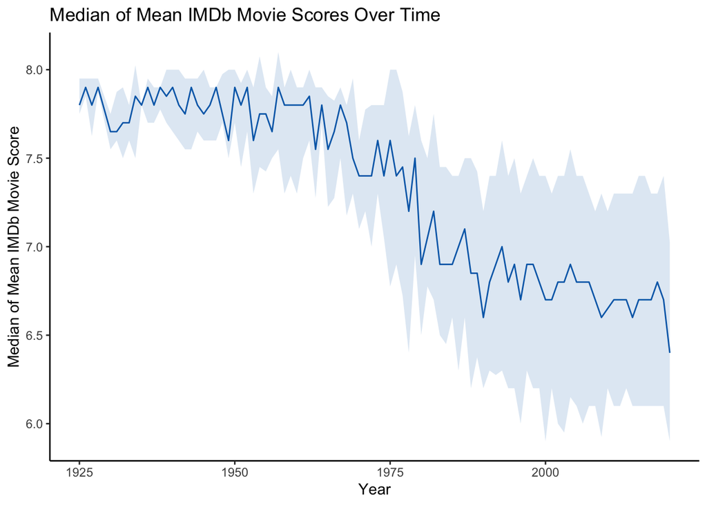

```r
ggplot(avgvotes)+
  geom_ribbon(aes(x=year,ymin=Q1,ymax=Q3), fill = "#006BB6", alpha = 0.15) +
  geom_line(aes(x=year,y=Median), col="#006BB6") +
  labs(x="Year", y="Median of Mean IMDb Movie Score", title="Median of Mean IMDb Movie Scores Over Time") +
  theme_classic()
```

[figure not shown]

```r
ggplot()+
  geom_ribbon(data = subset(genvotes, genre == "Action"), aes(x=year,ymin=Q1,ymax=Q3, fill = "Action"), alpha = 0.15) +
  geom_ribbon(data = subset(genvotes, genre == "Drama"), aes(x=year,ymin=Q1,ymax=Q3, fill = "Drama"), alpha = 0.15) +
  geom_line(data = subset(genvotes, genre == "Action"), aes(x=year,y=Median, col= "Action")) +
  geom_line(data = subset(genvotes, genre == "Drama"), aes(x=year,y=Median, col= "Drama")) +
  labs(x="Year", y="Median of Mean IMDb Movie Score", title="Median of Mean IMDb Movie Scores Over Time") +
  scale_fill_manual(name = "Genre", values = c("Action" = "#006BB6", "Drama" = "#F58426"))+
  scale_color_manual(name = "Genre", values = c("Action" = "#006BB6", "Drama" = "#F58426"))+
  theme_classic()
```

By gender, the overall trend of decreasing scores according to year of movie release remains salient. Men and women seem to follow largely the same pattern, with the exception of men giving marginally lower ratings than women for movies released in the 1980s to 2010s.

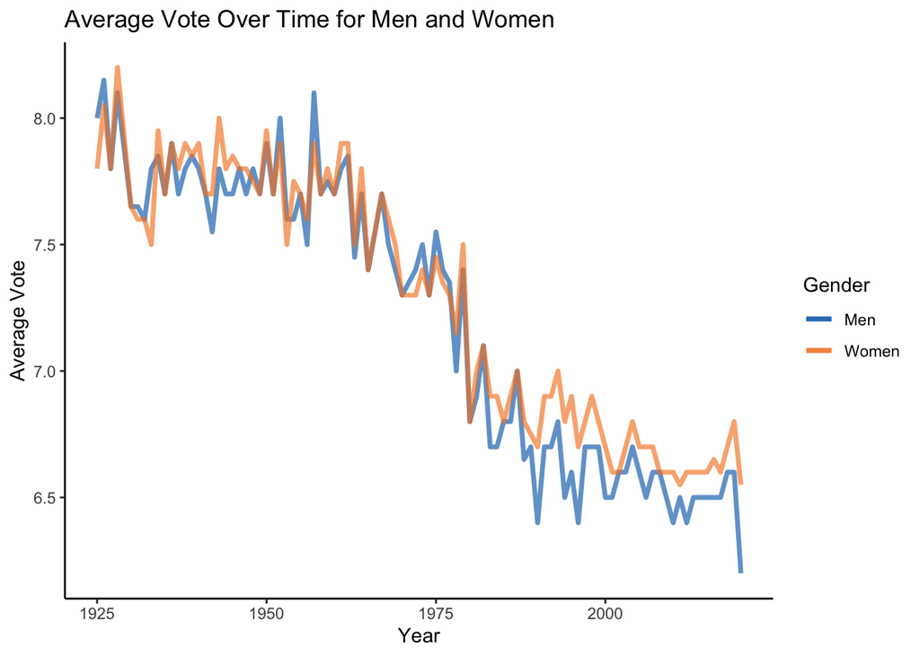

```r
ggplot(sumvotes) +
  geom_line(aes(x=year,y=men, col = "Men"), size = 1.25, alpha = 0.65) +
  geom_line(aes(x=year,y=women, col = "Women"), size = 1.25, alpha = 0.65)+
  labs(x = "Year", y = "Average Vote", title = "Average Vote Over Time for Men and Women") +
  scale_color_manual(name = "Gender", values = c("Women"="#F58426","Men"="#006BB6")) +
  theme_classic()
```

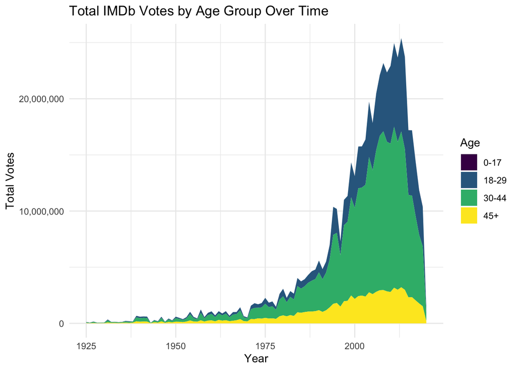

```r
ggplot(allsvotes) +
  geom_area(aes(x=Year, y = Votes, fill = Age)) +
  scale_fill_viridis(discrete = T, labels = c("0-17", "18-29", "30-44", "45+")) +
  scale_y_continuous(labels = comma) +
  labs(x = "Year", y = "Total Votes", title = "Total IMDb Votes by Age Group Over Time") +
  theme_minimal()
```

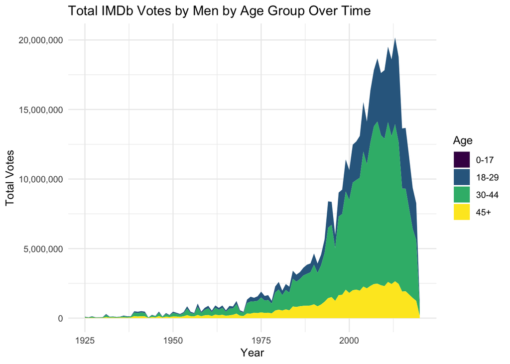

```r
ggplot(malesvotes) +
  geom_area(aes(x=Year, y = Votes, fill = Age)) +
  scale_fill_viridis(discrete = T, labels = c("0-17", "18-29", "30-44", "45+")) +
  scale_y_continuous(labels = comma) +
  labs(x = "Year", y = "Total Votes", title = "Total IMDb Votes by Men by Age Group Over Time") +
  theme_minimal()
```

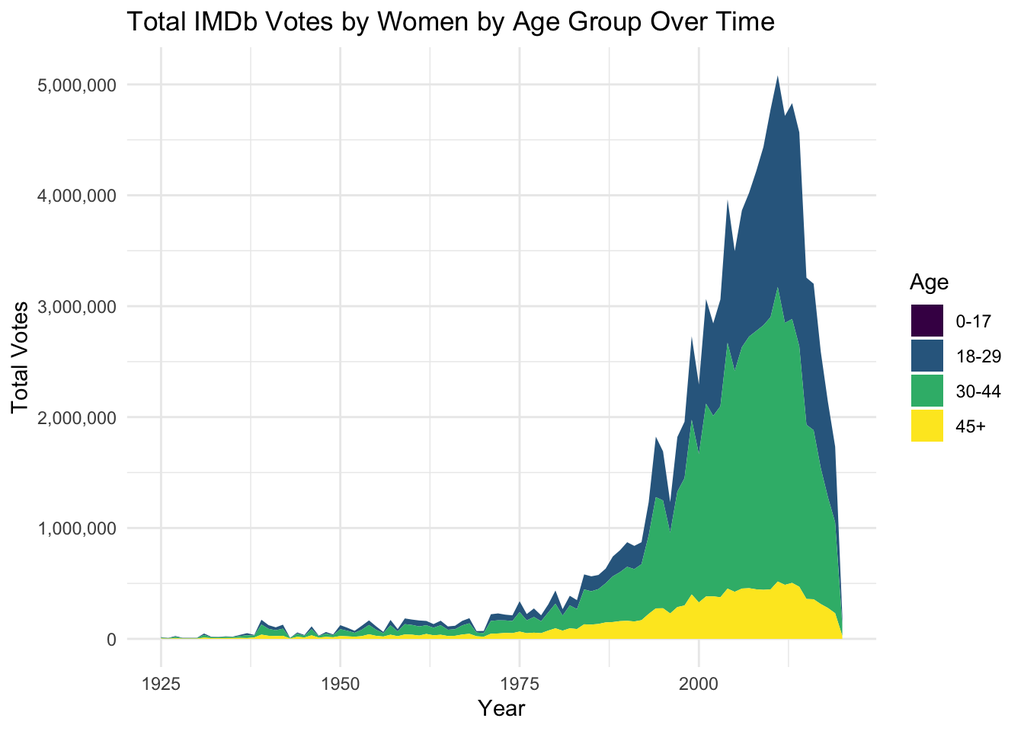

```r
ggplot(femalesvotes) +
  geom_area(aes(x=Year, y = Votes, fill = Age)) +
  scale_fill_viridis(discrete = T, labels = c("0-17", "18-29", "30-44", "45+")) +
  scale_y_continuous(labels = comma) +
  labs(x = "Year", y = "Total Votes", title = "Total IMDb Votes by Women by Age Group Over Time") +
  theme_minimal()
```